# 02-pandas-basics

به نام خدا  
دانشگاه صنعتی شریف - دانشکده مدیریت و اقتصاد شریف  
اقتصاد سنجی ۱  
ترم پاییز سال تحصیلی ۱۴۰۳-۱۴۰۲  
دکتر کوثر یوسفی

بخش دوم: مقدمات pandas

نگین جعفری، محمدمهدی جراحی

منبع: درس یادگیری ماشین دکتر سید عباس حسینی و درس اصول و تکنیک‌های علم داده دانشگاه برکلی

```python
#for jupyter
%matplotlib inline

import matplotlib.pyplot as plt
import seaborn as sns
import numpy as np
import pandas as pd

plt.style.use('fivethirtyeight')
sns.set_context("notebook")
```

There are Three core objects in pandas: the DataFrame, the Series and the indexes.

## DataFrames, Series and Indices

Data Frame: 2D data tabular data.

Series: 1D data. I usually think of it as columnar data.

Index: A sequence of row labels.

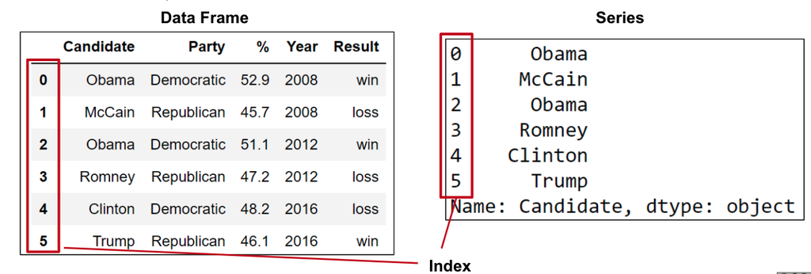

```python
pd.DataFrame({'Tehran': ['Rainy', 'Hazy'], 'Shiraz': ['Partly Sunny', 'Cloudy'], 'Ahwaz': ['Sunshine', 'Sunny']})
```

|  | Tehran | Shiraz | Ahwaz |
| --- | --- | --- | --- |
| 0 | Rainy | Partly Sunny | Sunshine |
| 1 | Hazy | Cloudy | Sunny |

The syntax for declaring a new DataFrame is a dictionary whose keys are the column names (Tehran and Shiraz and Ahwaz in this example), and whose values are a list of entries. to assign values to column labels we can use the below overload:

```python
pd.DataFrame({'Tehran': ['Rainy', 'Hazy'], 'Shiraz': ['Partly Sunny', 'Cloudy'], 'Ahwaz': ['Sunshine', 'Sunny']}, index = ['99/08/05','99/08/06'])
```

|  | Tehran | Shiraz | Ahwaz |
| --- | --- | --- | --- |
| 99/08/05 | Rainy | Partly Sunny | Sunshine |
| 99/08/06 | Hazy | Cloudy | Sunny |

### Series

A Series, by contrast, is a sequence of data values. If a DataFrame is a table, a Series is a list. And in fact you can create one with nothing more than a list:

```python
pd.Series(['Tehran', 'Shiraz', 'Ahwaz'])
# pd.Series(['Tehran', 'Shiraz', 'Ahwaz'], index = ['a','b', 'c'])
```

```
0    Tehran
1    Shiraz
2     Ahwaz
dtype: object
```

## Index

Index: A sequence of row labels. We can think of a Data Frame as a collection of Series that all share the same Index.

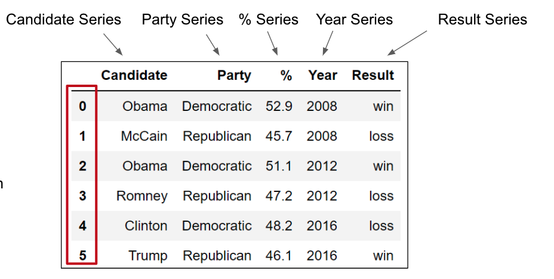

## Reading in DataFrames from Files

## Reading Data Files

Most of the time, we won't actually be creating our own data by hand. Instead, we'll be working with data that already exists.

[figure not shown]

Pandas has a number of very useful file reading tools. You can see them enumerated by typing "pd.re" and pressing tab. We'll be using read_csv today.

```python
elections = pd.read_csv("elections.csv")
elections # if we end a cell with an expression or variable name, the result will print
```

|  | Candidate | Party | % | Year | Result |
| --- | --- | --- | --- | --- | --- |
| 0 | Reagan | Republican | 50.7 | 1980 | win |
| 1 | Carter | Democratic | 41.0 | 1980 | loss |
| 2 | Anderson | Independent | 6.6 | 1980 | loss |
| 3 | Reagan | Republican | 58.8 | 1984 | win |
| 4 | Mondale | Democratic | 37.6 | 1984 | loss |
| 5 | Bush | Republican | 53.4 | 1988 | win |
| 6 | Dukakis | Democratic | 45.6 | 1988 | loss |
| 7 | Clinton | Democratic | 43.0 | 1992 | win |
| 8 | Bush | Republican | 37.4 | 1992 | loss |
| 9 | Perot | Independent | 18.9 | 1992 | loss |
| 10 | Clinton | Democratic | 49.2 | 1996 | win |
| 11 | Dole | Republican | 40.7 | 1996 | loss |
| 12 | Perot | Independent | 8.4 | 1996 | loss |
| 13 | Gore | Democratic | 48.4 | 2000 | loss |
| 14 | Bush | Republican | 47.9 | 2000 | win |
| 15 | Kerry | Democratic | 48.3 | 2004 | loss |
| 16 | Bush | Republican | 50.7 | 2004 | win |
| 17 | Obama | Democratic | 52.9 | 2008 | win |
| 18 | McCain | Republican | 45.7 | 2008 | loss |
| 19 | Obama | Democratic | 51.1 | 2012 | win |
| 20 | Romney | Republican | 47.2 | 2012 | loss |
| 21 | Clinton | Democratic | 48.2 | 2016 | loss |
| 22 | Trump | Republican | 46.1 | 2016 | win |

We can use the head command to return only a few rows of a dataframe.

```python
elections.head(7)
```

|  | Candidate | Party | % | Year | Result |
| --- | --- | --- | --- | --- | --- |
| 0 | Reagan | Republican | 50.7 | 1980 | win |
| 1 | Carter | Democratic | 41.0 | 1980 | loss |
| 2 | Anderson | Independent | 6.6 | 1980 | loss |
| 3 | Reagan | Republican | 58.8 | 1984 | win |
| 4 | Mondale | Democratic | 37.6 | 1984 | loss |
| 5 | Bush | Republican | 53.4 | 1988 | win |
| 6 | Dukakis | Democratic | 45.6 | 1988 | loss |

There is also a tail command.

```python
elections.tail(20).head(5)
```

|  | Candidate | Party | % | Year | Result |
| --- | --- | --- | --- | --- | --- |
| 3 | Reagan | Republican | 58.8 | 1984 | win |
| 4 | Mondale | Democratic | 37.6 | 1984 | loss |
| 5 | Bush | Republican | 53.4 | 1988 | win |
| 6 | Dukakis | Democratic | 45.6 | 1988 | loss |
| 7 | Clinton | Democratic | 43.0 | 1992 | win |

The read_csv command lets us specify a column to use an index. For example, we could have used Year as the index.

```python
elections_year_index = pd.read_csv("elections.csv", index_col = "Year")
elections_year_index.head(5)
#لزومی ندارد ایندکس یکتا باشد
```

| Year | Candidate | Party | % | Result |
| --- | --- | --- | --- | --- |
| 1980 | Reagan | Republican | 50.7 | win |
| 1980 | Carter | Democratic | 41.0 | loss |
| 1980 | Anderson | Independent | 6.6 | loss |
| 1984 | Reagan | Republican | 58.8 | win |
| 1984 | Mondale | Democratic | 37.6 | loss |

Alternately, we could have used the set_index commmand.

```python
elections_party_index = elections.set_index("Party")
elections_party_index.head(5)
```

| Party | Candidate | % | Year | Result |
| --- | --- | --- | --- | --- |
| Republican | Reagan | 50.7 | 1980 | win |
| Democratic | Carter | 41.0 | 1980 | loss |
| Independent | Anderson | 6.6 | 1980 | loss |
| Republican | Reagan | 58.8 | 1984 | win |
| Democratic | Mondale | 37.6 | 1984 | loss |

The set_index command (along with all other data frame methods) does not modify the dataframe. That is, the original "elections" is untouched. Note: There is a flag called "inplace" which does modify the calling dataframe.

```python
elections.head() #the index remains unchanged
```

|  | Candidate | Party | % | Year | Result |
| --- | --- | --- | --- | --- | --- |
| 0 | Reagan | Republican | 50.7 | 1980 | win |
| 1 | Carter | Democratic | 41.0 | 1980 | loss |
| 2 | Anderson | Independent | 6.6 | 1980 | loss |
| 3 | Reagan | Republican | 58.8 | 1984 | win |
| 4 | Mondale | Democratic | 37.6 | 1984 | loss |

By contrast, column names are ideally unique. For example, if we try to read in a file for which column names are not unique, Pandas will automatically rename any duplicates.

```python
dups = pd.read_csv("elections-duplicate.csv")
dups
```

|  | Candidate | Party | Party.1 | % | Year | Result |
| --- | --- | --- | --- | --- | --- | --- |
| 0 | Reagan | Republican | Republican | 50.7 | 1980 | win |
| 1 | Carter | Democratic | Democratic | 41.0 | 1980 | loss |
| 2 | Anderson | Independent | Independent | 6.6 | 1980 | loss |
| 3 | Reagan | Republican | Republican | 58.8 | 1984 | win |
| 4 | Mondale | Democratic | Democratic | 37.6 | 1984 | loss |
| 5 | Bush | Republican | Republican | 53.4 | 1988 | win |
| 6 | Dukakis | Democratic | Democratic | 45.6 | 1988 | loss |
| 7 | Clinton | Democratic | Democratic | 43.0 | 1992 | win |
| 8 | Bush | Republican | Republican | 37.4 | 1992 | loss |
| 9 | Perot | Independent | Independent | 18.9 | 1992 | loss |
| 10 | Clinton | Democratic | Democratic | 49.2 | 1996 | win |
| 11 | Dole | Republican | Republican | 40.7 | 1996 | loss |
| 12 | Perot | Independent | Independent | 8.4 | 1996 | loss |
| 13 | Gore | Democratic | Democratic | 48.4 | 2000 | loss |
| 14 | Bush | Republican | Republican | 47.9 | 2000 | win |
| 15 | Kerry | Democratic | Democratic | 48.3 | 2004 | loss |
| 16 | Bush | Republican | Republican | 50.7 | 2004 | win |
| 17 | Obama | Democratic | Democratic | 52.9 | 2008 | win |
| 18 | McCain | Republican | Republican | 45.7 | 2008 | loss |
| 19 | Obama | Democratic | Democratic | 51.1 | 2012 | win |
| 20 | Romney | Republican | Republican | 47.2 | 2012 | loss |
| 21 | Clinton | Democratic | Democratic | 48.2 | 2016 | loss |
| 22 | Trump | Republican | Republican | 46.1 | 2016 | win |

## The [] Operator

The DataFrame class has an indexing operator [] that lets you do a variety of different things. If your provide a String to the [] operator, you get back a Series corresponding to the requested label.

```python
elections_year_index.head(6)
```

| Year | Candidate | Party | % | Result |
| --- | --- | --- | --- | --- |
| 1980 | Reagan | Republican | 50.7 | win |
| 1980 | Carter | Democratic | 41.0 | loss |
| 1980 | Anderson | Independent | 6.6 | loss |
| 1984 | Reagan | Republican | 58.8 | win |
| 1984 | Mondale | Democratic | 37.6 | loss |
| 1988 | Bush | Republican | 53.4 | win |

```python
elections_year_index["Candidate"].head(6)
```

```
Year
1980      Reagan
1980      Carter
1980    Anderson
1984      Reagan
1984     Mondale
1988        Bush
Name: Candidate, dtype: object
```

The [] operator also accepts a list of strings. In this case, you get back a DataFrame corresponding to the requested strings.

```python
elections_year_index[["Candidate", "Party"]].head(6)
```

| Year | Candidate | Party |
| --- | --- | --- |
| 1980 | Reagan | Republican |
| 1980 | Carter | Democratic |
| 1980 | Anderson | Independent |
| 1984 | Reagan | Republican |
| 1984 | Mondale | Democratic |
| 1988 | Bush | Republican |

A list of one label also returns a DataFrame. This can be handy if you want your results as a DataFrame, not a series.

```python
elections_year_index[["Candidate"]].head(6)
```

| Year | Candidate |
| --- | --- |
| 1980 | Reagan |
| 1980 | Carter |
| 1980 | Anderson |
| 1984 | Reagan |
| 1984 | Mondale |
| 1988 | Bush |

Note that we can also use the to_frame method to turn a Series into a DataFrame.

```python
elections_year_index["Candidate"].to_frame().head(5)
```

| Year | Candidate |
| --- | --- |
| 1980 | Reagan |
| 1980 | Carter |
| 1980 | Anderson |
| 1984 | Reagan |
| 1984 | Mondale |

The [] operator also accepts numerical slices as arguments. In this case, we are indexing by row, not column!

```python
elections_year_index[0:4]
# row numbers not index
```

| Year | Candidate | Party | % | Result |
| --- | --- | --- | --- | --- |
| 1980 | Reagan | Republican | 50.7 | win |
| 1980 | Carter | Democratic | 41.0 | loss |
| 1980 | Anderson | Independent | 6.6 | loss |
| 1984 | Reagan | Republican | 58.8 | win |

If you provide a single argument to the [] operator, it tries to use it as a name. This is true even if the argument passed to [] is an integer.

```python
# elections_year_index[0] #this does not work, try uncommenting this to see it fail in action, woo
```

The following cells allow you to test your understanding.

```python
weird = pd.DataFrame({
    1:["topdog","botdog"],
    "1":["topcat","botcat"]
})
weird
```

|  | 1 | 1 |
| --- | --- | --- |
| 0 | topdog | topcat |
| 1 | botdog | botcat |

```python
weird[1] #try to predict the output
```

```
0    topdog
1    botdog
Name: 1, dtype: object
```

```python
weird["1"] #try to predict the output
```

```
0    topcat
1    botcat
Name: 1, dtype: object
```

```python
weird[1:] #try to predict the output
```

|  | 1 | 1 |
| --- | --- | --- |
| 1 | botdog | botcat |

## Boolean Array Selection

The `[]` operator also supports array of booleans as an input. In this case, the array must be exactly as long as the number of rows. The result is a filtered version of the data frame, where only rows corresponding to True appear.

```python
elections_year_index[[False, False, False, False, False,
          False, False, True, False, False,
          True, False, False, False, True,
          False, False, False, False, False,
          False, False, True]]
```

| Year | Candidate | Party | % | Result |
| --- | --- | --- | --- | --- |
| 1992 | Clinton | Democratic | 43.0 | win |
| 1996 | Clinton | Democratic | 49.2 | win |
| 2000 | Bush | Republican | 47.9 | win |
| 2016 | Trump | Republican | 46.1 | win |

One very common task in Data Science is filtering. Boolean Array Selection is one way to achieve this in Pandas. We start by observing logical operators like the equality operator can be applied to Pandas Series data to generate a Boolean Array. For example, we can compare the 'Result' column to the String 'win':

```python
elections_year_index.head(5)
```

| Year | Candidate | Party | % | Result |
| --- | --- | --- | --- | --- |
| 1980 | Reagan | Republican | 50.7 | win |
| 1980 | Carter | Democratic | 41.0 | loss |
| 1980 | Anderson | Independent | 6.6 | loss |
| 1984 | Reagan | Republican | 58.8 | win |
| 1984 | Mondale | Democratic | 37.6 | loss |

```python
iswin = elections_year_index['Result'] == 'win'
iswin.head(5)
```

```
Year
1980     True
1980    False
1980    False
1984     True
1984    False
Name: Result, dtype: bool
```

The output of the logical operator applied to the Series is another Series with the same name and index, but of datatype boolean. The entry at row #i represents the result of the application of that operator to the entry of the original Series at row #i.

Such a boolean Series can be used as an argument to the [] operator. For example, the following code creates a DataFrame of all election winners since 1980.

```python
elections_year_index[iswin]
```

| Year | Candidate | Party | % | Result |
| --- | --- | --- | --- | --- |
| 1980 | Reagan | Republican | 50.7 | win |
| 1984 | Reagan | Republican | 58.8 | win |
| 1988 | Bush | Republican | 53.4 | win |
| 1992 | Clinton | Democratic | 43.0 | win |
| 1996 | Clinton | Democratic | 49.2 | win |
| 2000 | Bush | Republican | 47.9 | win |
| 2004 | Bush | Republican | 50.7 | win |
| 2008 | Obama | Democratic | 52.9 | win |
| 2012 | Obama | Democratic | 51.1 | win |
| 2016 | Trump | Republican | 46.1 | win |

Above, we've assigned the result of the logical operator to a new variable called `iswin`. This is uncommon. Usually, the series is created and used on the same line. Such code is a little tricky to read at first, but you'll get used to it quickly.

```python
elections_year_index[elections_year_index['Result'] == 'win']
```

| Year | Candidate | Party | % | Result |
| --- | --- | --- | --- | --- |
| 1980 | Reagan | Republican | 50.7 | win |
| 1984 | Reagan | Republican | 58.8 | win |
| 1988 | Bush | Republican | 53.4 | win |
| 1992 | Clinton | Democratic | 43.0 | win |
| 1996 | Clinton | Democratic | 49.2 | win |
| 2000 | Bush | Republican | 47.9 | win |
| 2004 | Bush | Republican | 50.7 | win |
| 2008 | Obama | Democratic | 52.9 | win |
| 2012 | Obama | Democratic | 51.1 | win |
| 2016 | Trump | Republican | 46.1 | win |

We can select multiple criteria by creating multiple boolean Series and combining them using the `&` operator.

```python
win50plus = (elections_year_index['Result'] == 'win') & (elections_year_index['%'] < 50)
```

```python
win50plus.head(15)
```

```
Year
1980    False
1980    False
1980    False
1984    False
1984    False
1988    False
1988    False
1992     True
1992    False
1992    False
1996     True
1996    False
1996    False
2000    False
2000     True
dtype: bool
```

```python
elections_year_index[(elections_year_index['Result'] == 'win')
          & (elections_year_index['%'] < 50)]

# Note for Python experts: The reason we use the & symbol and not the word "and" is because the Python __and__
# method overrides the "&" operator, not the "and" operator.
```

| Year | Candidate | Party | % | Result |
| --- | --- | --- | --- | --- |
| 1992 | Clinton | Democratic | 43.0 | win |
| 1996 | Clinton | Democratic | 49.2 | win |
| 2000 | Bush | Republican | 47.9 | win |
| 2016 | Trump | Republican | 46.1 | win |

The | operator is the symbol for or.

```python
elections_year_index[(elections_year_index['Party'] == 'Republican')
          | (elections_year_index['Party'] == "Democratic")]
```

| Year | Candidate | Party | % | Result |
| --- | --- | --- | --- | --- |
| 1980 | Reagan | Republican | 50.7 | win |
| 1980 | Carter | Democratic | 41.0 | loss |
| 1984 | Reagan | Republican | 58.8 | win |
| 1984 | Mondale | Democratic | 37.6 | loss |
| 1988 | Bush | Republican | 53.4 | win |
| 1988 | Dukakis | Democratic | 45.6 | loss |
| 1992 | Clinton | Democratic | 43.0 | win |
| 1992 | Bush | Republican | 37.4 | loss |
| 1996 | Clinton | Democratic | 49.2 | win |
| 1996 | Dole | Republican | 40.7 | loss |
| 2000 | Gore | Democratic | 48.4 | loss |
| 2000 | Bush | Republican | 47.9 | win |
| 2004 | Kerry | Democratic | 48.3 | loss |
| 2004 | Bush | Republican | 50.7 | win |
| 2008 | Obama | Democratic | 52.9 | win |
| 2008 | McCain | Republican | 45.7 | loss |
| 2012 | Obama | Democratic | 51.1 | win |
| 2012 | Romney | Republican | 47.2 | loss |
| 2016 | Clinton | Democratic | 48.2 | loss |
| 2016 | Trump | Republican | 46.1 | win |

If we have multiple conditions (say Republican or Democratic), we can use the isin operator to simplify our code.

```python
elections_year_index['Party'].isin(["Republican", "Democratic"])
```

```
Year
1980     True
1980     True
1980    False
1984     True
1984     True
1988     True
1988     True
1992     True
1992     True
1992    False
1996     True
1996     True
1996    False
2000     True
2000     True
2004     True
2004     True
2008     True
2008     True
2012     True
2012     True
2016     True
2016     True
Name: Party, dtype: bool
```

```python
elections_year_index[elections_year_index['Party'].isin(["Republican", "Democratic"])]
```

| Year | Candidate | Party | % | Result |
| --- | --- | --- | --- | --- |
| 1980 | Reagan | Republican | 50.7 | win |
| 1980 | Carter | Democratic | 41.0 | loss |
| 1984 | Reagan | Republican | 58.8 | win |
| 1984 | Mondale | Democratic | 37.6 | loss |
| 1988 | Bush | Republican | 53.4 | win |
| 1988 | Dukakis | Democratic | 45.6 | loss |
| 1992 | Clinton | Democratic | 43.0 | win |
| 1992 | Bush | Republican | 37.4 | loss |
| 1996 | Clinton | Democratic | 49.2 | win |
| 1996 | Dole | Republican | 40.7 | loss |
| 2000 | Gore | Democratic | 48.4 | loss |
| 2000 | Bush | Republican | 47.9 | win |
| 2004 | Kerry | Democratic | 48.3 | loss |
| 2004 | Bush | Republican | 50.7 | win |
| 2008 | Obama | Democratic | 52.9 | win |
| 2008 | McCain | Republican | 45.7 | loss |
| 2012 | Obama | Democratic | 51.1 | win |
| 2012 | Romney | Republican | 47.2 | loss |
| 2016 | Clinton | Democratic | 48.2 | loss |
| 2016 | Trump | Republican | 46.1 | win |

An alternate simpler way to get back a specific set of rows is to use the `query` command.

```python
elections_year_index.query("Result == 'win' and Year < 2000")
```

| Year | Candidate | Party | % | Result |
| --- | --- | --- | --- | --- |
| 1980 | Reagan | Republican | 50.7 | win |
| 1984 | Reagan | Republican | 58.8 | win |
| 1988 | Bush | Republican | 53.4 | win |
| 1992 | Clinton | Democratic | 43.0 | win |
| 1996 | Clinton | Democratic | 49.2 | win |

## loc and iloc

```python
elections.head(5)
```

|  | Candidate | Party | % | Year | Result |
| --- | --- | --- | --- | --- | --- |
| 0 | Reagan | Republican | 50.7 | 1980 | win |
| 1 | Carter | Democratic | 41.0 | 1980 | loss |
| 2 | Anderson | Independent | 6.6 | 1980 | loss |
| 3 | Reagan | Republican | 58.8 | 1984 | win |
| 4 | Mondale | Democratic | 37.6 | 1984 | loss |

```python
# elections.loc[[0, 1, 2, 3, 4], ['Candidate','Party', 'Year']]
elections_year_index.loc[[1980, 1984], ['Candidate','Party']]

# row index (not row number)
```

| Year | Candidate | Party |
| --- | --- | --- |
| 1980 | Reagan | Republican |
| 1980 | Carter | Democratic |
| 1980 | Anderson | Independent |
| 1984 | Reagan | Republican |
| 1984 | Mondale | Democratic |

```python
elections_year_index.loc[[1980, 1984],]
```

| Year | Candidate | Party | % | Result |
| --- | --- | --- | --- | --- |
| 1980 | Reagan | Republican | 50.7 | win |
| 1980 | Carter | Democratic | 41.0 | loss |
| 1980 | Anderson | Independent | 6.6 | loss |
| 1984 | Reagan | Republican | 58.8 | win |
| 1984 | Mondale | Democratic | 37.6 | loss |

Loc also supports slicing (for all types, including numeric and string labels!). Note that the slicing for loc is **inclusive**, even for numeric slices.

```python
elections.loc[0:4, 'Candidate':'%']

# row indices not numbers
```

|  | Candidate | Party | % |
| --- | --- | --- | --- |
| 0 | Reagan | Republican | 50.7 |
| 1 | Carter | Democratic | 41.0 |
| 2 | Anderson | Independent | 6.6 |
| 3 | Reagan | Republican | 58.8 |
| 4 | Mondale | Democratic | 37.6 |

```python
elections_year_index.loc[1980:1984, 'Candidate':'Party']
```

| Year | Candidate | Party |
| --- | --- | --- |
| 1980 | Reagan | Republican |
| 1980 | Carter | Democratic |
| 1980 | Anderson | Independent |
| 1984 | Reagan | Republican |
| 1984 | Mondale | Democratic |

If we provide only a single label for the column argument, we get back a Series.

```python
elections.loc[0:4, 'Candidate']
```

```
0      Reagan
1      Carter
2    Anderson
3      Reagan
4     Mondale
Name: Candidate, dtype: object
```

If we want a data frame instead and don't want to use to_frame, we can provde a list containing the column name.

```python
elections.loc[0:4, ['Candidate']]
```

|  | Candidate |
| --- | --- |
| 0 | Reagan |
| 1 | Carter |
| 2 | Anderson |
| 3 | Reagan |
| 4 | Mondale |

If we give only one row but many column labels, we'll get back a Series corresponding to a row of the table. This new Series has a neat index, where each entry is the name of the column that the data came from.

```python
elections.head(1)
```

|  | Candidate | Party | % | Year | Result |
| --- | --- | --- | --- | --- | --- |
| 0 | Reagan | Republican | 50.7 | 1980 | win |

```python
elections.loc[0, 'Candidate':'Year']
```

```
Candidate        Reagan
Party        Republican
%                  50.7
Year               1980
Name: 0, dtype: object
```

```python
elections.loc[[0], 'Candidate':'Year']
```

|  | Candidate | Party | % | Year |
| --- | --- | --- | --- | --- |
| 0 | Reagan | Republican | 50.7 | 1980 |

If we omit the column argument altogether, the default behavior is to retrieve all columns.

```python
elections.loc[[2, 4, 5]]
```

|  | Candidate | Party | % | Year | Result |
| --- | --- | --- | --- | --- | --- |
| 2 | Anderson | Independent | 6.6 | 1980 | loss |
| 4 | Mondale | Democratic | 37.6 | 1984 | loss |
| 5 | Bush | Republican | 53.4 | 1988 | win |

Loc also supports boolean array inputs instead of labels. If the arrays are too short, loc assumes the missing values are False. **Note: For newer versions of Pandas, loc will not assume that the missing values are False and instead throw an error.**

```python
# elections.loc[[True, False, False, True], [True, False, False, True]]
elections.loc[elections['Result'] == 'win', [True, False, False, True, True]]
```

|  | Candidate | Year | Result |
| --- | --- | --- | --- |
| 0 | Reagan | 1980 | win |
| 3 | Reagan | 1984 | win |
| 5 | Bush | 1988 | win |
| 7 | Clinton | 1992 | win |
| 10 | Clinton | 1996 | win |
| 14 | Bush | 2000 | win |
| 16 | Bush | 2004 | win |
| 17 | Obama | 2008 | win |
| 19 | Obama | 2012 | win |
| 22 | Trump | 2016 | win |

```python
elections.loc[[0, 3], ['Candidate', 'Year']]
```

|  | Candidate | Year |
| --- | --- | --- |
| 0 | Reagan | 1980 |
| 3 | Reagan | 1984 |

We can use boolean array arguments for one axis of the data, and labels for the other.

```python
# elections.loc[[True, False, False, True], 'Candidate':'%']
elections.loc[elections['Result'] == 'win', 'Candidate':'%']
```

|  | Candidate | Party | % |
| --- | --- | --- | --- |
| 0 | Reagan | Republican | 50.7 |
| 3 | Reagan | Republican | 58.8 |
| 5 | Bush | Republican | 53.4 |
| 7 | Clinton | Democratic | 43.0 |
| 10 | Clinton | Democratic | 49.2 |
| 14 | Bush | Republican | 47.9 |
| 16 | Bush | Republican | 50.7 |
| 17 | Obama | Democratic | 52.9 |
| 19 | Obama | Democratic | 51.1 |
| 22 | Trump | Republican | 46.1 |

A student asks what happens if you give scalar arguments for the requested rows AND columns. The answer is that you get back just a single value.

```python
elections.loc[0, 'Candidate']
```

```
'Reagan'
```

### iloc

loc's cousin iloc is very similar, but is used to access based on numerical position instead of label. For example, to access to the top 3 rows and top 3 columns of a table, we can use [0:3, 0:3]. iloc slicing is **exclusive**, just like standard Python slicing of numerical values.

```python
elections.head(5)
```

|  | Candidate | Party | % | Year | Result |
| --- | --- | --- | --- | --- | --- |
| 0 | Reagan | Republican | 50.7 | 1980 | win |
| 1 | Carter | Democratic | 41.0 | 1980 | loss |
| 2 | Anderson | Independent | 6.6 | 1980 | loss |
| 3 | Reagan | Republican | 58.8 | 1984 | win |
| 4 | Mondale | Democratic | 37.6 | 1984 | loss |

```python
# elections.iloc[0:3, 0:3]
elections.iloc[[1, 1, 0, 3], 0:3]
```

|  | Candidate | Party | % |
| --- | --- | --- | --- |
| 1 | Carter | Democratic | 41.0 |
| 1 | Carter | Democratic | 41.0 |
| 0 | Reagan | Republican | 50.7 |
| 3 | Reagan | Republican | 58.8 |

We will use both loc and iloc in the course. Loc is generally preferred for a number of reasons, for example:

1. It is harder to make mistakes since you have to literally write out what you want to get.
2. Code is easier to read, because the reader doesn't have to know e.g. what column #31 represents.
3. It is robust against permutations of the data, e.g. the social security administration switches the order of two columns.

However, iloc is sometimes more convenient. We'll provide examples of when iloc is the superior choice.

## Quick Challenge

```python
elections
```

|  | Candidate | Party | % | Year | Result |
| --- | --- | --- | --- | --- | --- |
| 0 | Reagan | Republican | 50.7 | 1980 | win |
| 1 | Carter | Democratic | 41.0 | 1980 | loss |
| 2 | Anderson | Independent | 6.6 | 1980 | loss |
| 3 | Reagan | Republican | 58.8 | 1984 | win |
| 4 | Mondale | Democratic | 37.6 | 1984 | loss |
| 5 | Bush | Republican | 53.4 | 1988 | win |
| 6 | Dukakis | Democratic | 45.6 | 1988 | loss |
| 7 | Clinton | Democratic | 43.0 | 1992 | win |
| 8 | Bush | Republican | 37.4 | 1992 | loss |
| 9 | Perot | Independent | 18.9 | 1992 | loss |
| 10 | Clinton | Democratic | 49.2 | 1996 | win |
| 11 | Dole | Republican | 40.7 | 1996 | loss |
| 12 | Perot | Independent | 8.4 | 1996 | loss |
| 13 | Gore | Democratic | 48.4 | 2000 | loss |
| 14 | Bush | Republican | 47.9 | 2000 | win |
| 15 | Kerry | Democratic | 48.3 | 2004 | loss |
| 16 | Bush | Republican | 50.7 | 2004 | win |
| 17 | Obama | Democratic | 52.9 | 2008 | win |
| 18 | McCain | Republican | 45.7 | 2008 | loss |
| 19 | Obama | Democratic | 51.1 | 2012 | win |
| 20 | Romney | Republican | 47.2 | 2012 | loss |
| 21 | Clinton | Democratic | 48.2 | 2016 | loss |
| 22 | Trump | Republican | 46.1 | 2016 | win |

```python
elections.loc[elections["%"] > 50, ["Candidate", "Year"]].head(3)
```

|  | Candidate | Year |
| --- | --- | --- |
| 0 | Reagan | 1980 |
| 3 | Reagan | 1984 |
| 5 | Bush | 1988 |

```python
elections.loc[elections["%"] > 50, ["Candidate", "Year"]].iloc[0:3, :]
```

|  | Candidate | Year |
| --- | --- | --- |
| 0 | Reagan | 1980 |
| 3 | Reagan | 1984 |
| 5 | Bush | 1988 |

## Sampling

Pandas dataframes also make it easy to get a sample. We simply use the `sample` method and provide the number of samples that we'd like as the arugment. Sampling is done without replacement by default. Set `replace=True` if you want replacement.

```python
elections.sample(3)
```

|  | Candidate | Party | % | Year | Result |
| --- | --- | --- | --- | --- | --- |
| 19 | Obama | Democratic | 51.1 | 2012 | win |
| 4 | Mondale | Democratic | 37.6 | 1984 | loss |
| 14 | Bush | Republican | 47.9 | 2000 | win |

```python
elections.query("Year < 1992").sample(5, replace=True)
```

|  | Candidate | Party | % | Year | Result |
| --- | --- | --- | --- | --- | --- |
| 3 | Reagan | Republican | 58.8 | 1984 | win |
| 6 | Dukakis | Democratic | 45.6 | 1988 | loss |
| 3 | Reagan | Republican | 58.8 | 1984 | win |
| 1 | Carter | Democratic | 41.0 | 1980 | loss |
| 6 | Dukakis | Democratic | 45.6 | 1988 | loss |

## Handy Properties and Utility Functions for Series and DataFrames

#### Python Operations on Numerical DataFrames and Series

Consider a series of only the vote percentages of election winners.

```python
winners = elections.query("Result == 'win'")["%"]
winners
```

```
0     50.7
3     58.8
5     53.4
7     43.0
10    49.2
14    47.9
16    50.7
17    52.9
19    51.1
22    46.1
Name: %, dtype: float64
```

We can perform various Python operations (including numpy operations) to DataFrames and Series.

```python
max(winners)
```

```
58.8
```

```python
np.mean(winners)
```

```
50.38000000000001
```

We can also apply mathematical operations to a DataFrame so long as it has only numerical data.

```python
(elections[["%", "Year"]] + 3).head(5)

# 3 is added to every number.
```

|  | % | Year |
| --- | --- | --- |
| 0 | 53.7 | 1983 |
| 1 | 44.0 | 1983 |
| 2 | 9.6 | 1983 |
| 3 | 61.8 | 1987 |
| 4 | 40.6 | 1987 |

#### Handy Utility Methods

The head, shape, size, and describe methods can be used to quickly get a good sense of the data we're working with. For example:

```python
elections.head(3)
```

|  | Candidate | Party | % | Year | Result |
| --- | --- | --- | --- | --- | --- |
| 0 | Reagan | Republican | 50.7 | 1980 | win |
| 1 | Carter | Democratic | 41.0 | 1980 | loss |
| 2 | Anderson | Independent | 6.6 | 1980 | loss |

```python
elections.size
```

```
115
```

The fact that the size is 115 means our data file is relatively small, with only 115 total entries.

```python
elections.shape
```

```
(23, 5)
```

```python
elections.describe()
```

|  | % | Year |
| --- | --- | --- |
| count | 23.000000 | 23.000000 |
| mean | 42.513043 | 1996.869565 |
| std | 13.476117 | 11.627961 |
| min | 6.600000 | 1980.000000 |
| 25% | 40.850000 | 1988.000000 |
| 50% | 47.200000 | 1996.000000 |
| 75% | 49.950000 | 2006.000000 |
| max | 58.800000 | 2016.000000 |

Above, we see a quick summary of all the data.

We can get a direct reference to the index using .index.

```python
elections_party_index.index
```

```
Index(['Republican', 'Democratic', 'Independent', 'Republican', 'Democratic',
       'Republican', 'Democratic', 'Democratic', 'Republican', 'Independent',
       'Democratic', 'Republican', 'Independent', 'Democratic', 'Republican',
       'Democratic', 'Republican', 'Democratic', 'Republican', 'Democratic',
       'Republican', 'Democratic', 'Republican'],
      dtype='object', name='Party')
```

We can also access individual properties of the index, for example, `elections_year_index.index.name`.

```python
elections_year_index.index.name
```

```
'Year'
```

It turns out the columns also have an Index. We can access this index by using `.columns`.

```python
elections.columns
```

```
Index(['Candidate', 'Party', '%', 'Year', 'Result'], dtype='object')
```

There are also a ton of useful utility methods we can use with Data Frames and Series. For example, we can create a copy of a data frame sorted by a specific column using `sort_values`.

```python
elections.sort_values('%')
```

|  | Candidate | Party | % | Year | Result |
| --- | --- | --- | --- | --- | --- |
| 2 | Anderson | Independent | 6.6 | 1980 | loss |
| 12 | Perot | Independent | 8.4 | 1996 | loss |
| 9 | Perot | Independent | 18.9 | 1992 | loss |
| 8 | Bush | Republican | 37.4 | 1992 | loss |
| 4 | Mondale | Democratic | 37.6 | 1984 | loss |
| 11 | Dole | Republican | 40.7 | 1996 | loss |
| 1 | Carter | Democratic | 41.0 | 1980 | loss |
| 7 | Clinton | Democratic | 43.0 | 1992 | win |
| 6 | Dukakis | Democratic | 45.6 | 1988 | loss |
| 18 | McCain | Republican | 45.7 | 2008 | loss |
| 22 | Trump | Republican | 46.1 | 2016 | win |
| 20 | Romney | Republican | 47.2 | 2012 | loss |
| 14 | Bush | Republican | 47.9 | 2000 | win |
| 21 | Clinton | Democratic | 48.2 | 2016 | loss |
| 15 | Kerry | Democratic | 48.3 | 2004 | loss |
| 13 | Gore | Democratic | 48.4 | 2000 | loss |
| 10 | Clinton | Democratic | 49.2 | 1996 | win |
| 16 | Bush | Republican | 50.7 | 2004 | win |
| 0 | Reagan | Republican | 50.7 | 1980 | win |
| 19 | Obama | Democratic | 51.1 | 2012 | win |
| 17 | Obama | Democratic | 52.9 | 2008 | win |
| 5 | Bush | Republican | 53.4 | 1988 | win |
| 3 | Reagan | Republican | 58.8 | 1984 | win |

As mentioned before, all Data Frame methods return a copy and do **not** modify the original data structure, unless you set inplace to True.

```python
elections.head(5)
```

|  | Candidate | Party | % | Year | Result |
| --- | --- | --- | --- | --- | --- |
| 0 | Reagan | Republican | 50.7 | 1980 | win |
| 1 | Carter | Democratic | 41.0 | 1980 | loss |
| 2 | Anderson | Independent | 6.6 | 1980 | loss |
| 3 | Reagan | Republican | 58.8 | 1984 | win |
| 4 | Mondale | Democratic | 37.6 | 1984 | loss |

If we want to sort in reverse order, we can set `ascending=False`.

```python
elections.sort_values('%', ascending=False)
```

|  | Candidate | Party | % | Year | Result |
| --- | --- | --- | --- | --- | --- |
| 3 | Reagan | Republican | 58.8 | 1984 | win |
| 5 | Bush | Republican | 53.4 | 1988 | win |
| 17 | Obama | Democratic | 52.9 | 2008 | win |
| 19 | Obama | Democratic | 51.1 | 2012 | win |
| 0 | Reagan | Republican | 50.7 | 1980 | win |
| 16 | Bush | Republican | 50.7 | 2004 | win |
| 10 | Clinton | Democratic | 49.2 | 1996 | win |
| 13 | Gore | Democratic | 48.4 | 2000 | loss |
| 15 | Kerry | Democratic | 48.3 | 2004 | loss |
| 21 | Clinton | Democratic | 48.2 | 2016 | loss |
| 14 | Bush | Republican | 47.9 | 2000 | win |
| 20 | Romney | Republican | 47.2 | 2012 | loss |
| 22 | Trump | Republican | 46.1 | 2016 | win |
| 18 | McCain | Republican | 45.7 | 2008 | loss |
| 6 | Dukakis | Democratic | 45.6 | 1988 | loss |
| 7 | Clinton | Democratic | 43.0 | 1992 | win |
| 1 | Carter | Democratic | 41.0 | 1980 | loss |
| 11 | Dole | Republican | 40.7 | 1996 | loss |
| 4 | Mondale | Democratic | 37.6 | 1984 | loss |
| 8 | Bush | Republican | 37.4 | 1992 | loss |
| 9 | Perot | Independent | 18.9 | 1992 | loss |
| 12 | Perot | Independent | 8.4 | 1996 | loss |
| 2 | Anderson | Independent | 6.6 | 1980 | loss |

We can also use `sort_values` on Series objects.

```python
elections['%'].sort_values().head(10)
```

```
2      6.6
12     8.4
9     18.9
8     37.4
4     37.6
11    40.7
1     41.0
7     43.0
6     45.6
18    45.7
Name: %, dtype: float64
```

For Series, the `value_counts` method is often quite handy.

```python
elections['Party'].value_counts()
```

```
Party
Republican     10
Democratic     10
Independent     3
Name: count, dtype: int64
```

Also commonly used is the `unique` method, which returns all unique values as a numpy array.

```python
elections['Party'].unique()
```

```
array(['Republican', 'Democratic', 'Independent'], dtype=object)
```